# Acot11 Final

# Preprocessing

```r
miceWT<-c("ACOT07","ACOT05","ACOT02","ACOT17","ACOT24") #
miceKO<-c("ACOT04","ACOT03","ACOT10","ACOT11","ACOT13","ACOT18","ACOT19","ACOT20","ACOT22","ACOT14") #
miceHT<-c("ACOT06","ACOT01","ACOT08","ACOT09","ACOT12","ACOT16","ACOT21","ACOT23","ACOT26")
BXDBL6<-c("BL601","BL602","BL606","BL609","BL610","BL611","BL612","BL614","BL616","BL6V1","BL6V2","BL6V3")
#miceWT<-miceWT[-which(miceWT=="ACOT15")]
miceWTACOT<-miceWT
miceR1<-c(miceWT,miceKO,miceHT)
miceWT<-c(miceWT,BXDBL6)


allmice<-c(miceWT,miceKO,miceHT)

# Create data matrix
mdata<-matrix(ncol=length(allmice),nrow=8*10800) # 10800 = nb epochs per file
colnames(mdata)<-allmice

# read files
for (mouse in allmice){

  # data we will append to mdata
  data<-c()

  fi<-list.files("FinalScoringAcot11/",paste("^",mouse,sep=""))
  data<-c(data,as.character(read.table(paste("FinalScoringAcot11/",fi,sep=""))$V1))

  mdata[,mouse]<-data
}

# Replace R1
for (mouse in miceR1){

  # data we will append to mdata
  data<-c()

  data<-c(data,as.character(read.table(paste(mouse,"R1.txt",sep=""))$V1))

  mdata[seq(43201,64800),mouse]<-data
}
```

## Get separation range

1 epoch = 4 seconds recording for 4 days 6h SD 3rd day Light-Dark cycle

```r
# 900 epochs = 1h
Hours<-c()
for (i in seq(1,24)){Hours<-c(Hours,rep(i,900))}
Hours<-rep(Hours,4)

# Days
Days<-c()
for (i in seq(1,4)){Days<-c(Days,rep(i,21600))}

# Light Dark cycle by 6h
LD<-c()
for (i in c("L1","L2","D1","D2")){LD<-c(LD,rep(i,5400))}
LD<-rep(LD,4)
LD[Days==3 & LD == "L1"]<-"L1SD" # SD
```

## BXD data

Genotype near Acot11 for BXD dataset

```r
WithVariant<- c('BXD045','BXD048','BXD098','BXD050','BXD051','BXD055','BXD056','BXD064','BXD065','BXD097','BXD067','BXD070','BXD071','BXD073','BXD103','BXD079','BXD081','BXD084','BXD085','BXD089')
WithoutVariant<- c('BXD043','BXD044','BXD049','BXD061','BXD066','BXD075','BXD083','BXD087','BXD090','BXD095','BXD096','BXD100','BXD101')
```

Read BXD Data

```r
BXDmdata<-matrix(ncol=0,nrow=8*10800)
BXDStrain<-c()
for (mouse in c(WithVariant,WithoutVariant)){
   mouseshort<-gsub("BXD","",mouse)
   fi<-list.files("BXD_Data/",paste("^",mouseshort,sep=""))
   for (f in fi){
      BXDStrain<-c(BXDStrain,mouse)
      data<-as.character(read.table(paste("BXD_Data/",f,sep=""))$V1)
      BXDmdata<-cbind(BXDmdata,data)
      colnames(BXDmdata)[ncol(BXDmdata)]<-f
   }
}
```

Get DBA2J and F1

```r
BXDDBF1mdata<-matrix(ncol=0,nrow=8*10800)
BXDDBF1Strain<-c()
for (mouse in c("DBA","DBF","BDF")){
   mouseshort<-gsub("BXD","",mouse)
   fi<-list.files("BXD_Data/",paste("^",mouseshort,sep=""))
   for (f in fi){
      BXDDBF1Strain<-c(BXDDBF1Strain,mouse)
      data<-as.character(read.table(paste("BXD_Data/",f,sep=""))$V1)
      BXDDBF1mdata<-cbind(BXDDBF1mdata,data)
      colnames(BXDDBF1mdata)[ncol(BXDDBF1mdata)]<-f
   }
}
```

## Functions

Count NREM sleep event

```r
NREMcount<-function(mdata,mouse){
  tmpdata<-as.character(mdata[,mouse])
  nbNREM<-0
  if ("n" %in% names(table(tmpdata))){nbNREM<-table(tmpdata)["n"]}
  nb2<-0
  if ("2" %in% names(table(tmpdata))){nb2<-table(tmpdata)["2"]}
  result<-(nbNREM+nb2)/15
  #result<-(nbNREM)/15
  return(result)
}

GetGain<-function(interval,ref="Own"){
  if (interval == "12-24"){
    seqData<-Days==3 & (LD == "D1" | LD == "D2")
    seqRefB1<-Days==1 & (LD == "D1" | LD == "D2")
    seqRefB2<-Days==2 & (LD == "D1" | LD == "D2")
  }

  if (interval == "12-24-Day4"){
    seqData<-Days==4 & (LD == "D1" | LD == "D2")
    seqRefB1<-Days==1 & (LD == "D1" | LD == "D2")
    seqRefB2<-Days==2 & (LD == "D1" | LD == "D2")
  }

  if (interval == "12-18"){
    seqData<-Days==3 & LD == "D1"
    seqRefB1<-Days==1 & LD == "D1"
    seqRefB2<-Days==2 & LD == "D1"
  }

  if (interval == "12-18-Day4"){
    seqData<-Days==4 & LD == "D1"
    seqRefB1<-Days==1 & LD == "D1"
    seqRefB2<-Days==2 & LD == "D1"
  }

  if (interval == "18-24"){
    seqData<-Days==3 & LD == "D2"
    seqRefB1<-Days==1 & LD == "D2"
    seqRefB2<-Days==2 & LD == "D2"
  }
  if (interval == "18-24-Day4"){
    seqData<-Days==4 & LD == "D2"
    seqRefB1<-Days==1 & LD == "D2"
    seqRefB2<-Days==2 & LD == "D2"
  }

  if (interval == "24h"){
    seqData<-(Days==3 & (LD == "D2" | LD == "D1" | LD == "L2")) | (Days==4 & (LD == "L1"))
    seqRefB1<-Days==1
    seqRefB2<-Days==2
  }

  if (interval == "24h-Day4"){
    seqData<-Days==4
    seqRefB1<-Days==1
    seqRefB2<-Days==2
  }

  mdatafilt<-mdata[seqData,]
  BXDDBF1mdatafilt<-BXDDBF1mdata[seqData ,]
  BXDmdatafilt<-BXDmdata[seqData,]
  mdatafilt_B1<-mdata[seqRefB1,]
  mdatafilt_B2<-mdata[seqRefB2,]
  BXDDBF1mdatafilt_B1<-BXDDBF1mdata[seqRefB1 ,]
  BXDDBF1mdatafilt_B2<-BXDDBF1mdata[seqRefB2 ,]
  BXDmdatafilt_B1<-BXDmdata[seqRefB1,]
  BXDmdatafilt_B2<-BXDmdata[seqRefB2,]

  # C57BL6
  BXD_C57BL6_NREMGain<-c()
  BXD_C57BL6_NREMGain_B1<-c()
  BXD_C57BL6_NREMGain_B2<-c()
  for (i in BXDBL6){
    BXD_C57BL6_NREMGain<-c(BXD_C57BL6_NREMGain,NREMcount(mdatafilt,i))
    BXD_C57BL6_NREMGain_B1<-c(BXD_C57BL6_NREMGain_B1,NREMcount(mdatafilt_B1,i))
    BXD_C57BL6_NREMGain_B2<-c(BXD_C57BL6_NREMGain_B2,NREMcount(mdatafilt_B2,i))
  }
  BXD_C57BL6_NREMGain_Ref<-(BXD_C57BL6_NREMGain_B1+BXD_C57BL6_NREMGain_B2)/2
  #print("C57 OK ")

  BXD_DBA2J_NREMGain<-c()
  BXD_DBA2J_NREMGain_B1<-c()
  BXD_DBA2J_NREMGain_B2<-c()
  i<-"DBA"
  for (j in which(BXDDBF1Strain==i)){
    BXD_DBA2J_NREMGain<-c(BXD_DBA2J_NREMGain,NREMcount(BXDDBF1mdatafilt,colnames(BXDDBF1mdata)[j]))
    BXD_DBA2J_NREMGain_B1<-c(BXD_DBA2J_NREMGain_B1,NREMcount(BXDDBF1mdatafilt_B1,colnames(BXDDBF1mdata)[j]))
    BXD_DBA2J_NREMGain_B2<-c(BXD_DBA2J_NREMGain_B2,NREMcount(BXDDBF1mdatafilt_B2,colnames(BXDDBF1mdata)[j]))
  }
  BXD_DBA2J_NREMGain_Ref<-(BXD_DBA2J_NREMGain_B1+BXD_DBA2J_NREMGain_B2)/2
  #print("DBA OK ")

  BXD_DBF1_NREMGain<-c()
  BXD_DBF1_NREMGain_B1<-c()
  BXD_DBF1_NREMGain_B2<-c()
  i<-"DBF"
  for (j in which(BXDDBF1Strain==i)){
    BXD_DBF1_NREMGain<-c(BXD_DBF1_NREMGain,NREMcount(BXDDBF1mdatafilt,colnames(BXDDBF1mdata)[j]))
    BXD_DBF1_NREMGain_B1<-c(BXD_DBF1_NREMGain_B1,NREMcount(BXDDBF1mdatafilt_B1,colnames(BXDDBF1mdata)[j]))
    BXD_DBF1_NREMGain_B2<-c(BXD_DBF1_NREMGain_B2,NREMcount(BXDDBF1mdatafilt_B2,colnames(BXDDBF1mdata)[j]))
  }
  BXD_DBF1_NREMGain_Ref<-(BXD_DBF1_NREMGain_B1+BXD_DBF1_NREMGain_B2)/2
  #print("DB OK ")

  BXD_BDF1_NREMGain<-c()
  BXD_BDF1_NREMGain_B1<-c()
  BXD_BDF1_NREMGain_B2<-c()
  i<-"BDF"
  for (j in which(BXDDBF1Strain==i)){
    BXD_BDF1_NREMGain<-c(BXD_BDF1_NREMGain,NREMcount(BXDDBF1mdatafilt,colnames(BXDDBF1mdata)[j]))
    BXD_BDF1_NREMGain_B1<-c(BXD_BDF1_NREMGain_B1,NREMcount(BXDDBF1mdatafilt_B1,colnames(BXDDBF1mdata)[j]))
    BXD_BDF1_NREMGain_B2<-c(BXD_BDF1_NREMGain_B2,NREMcount(BXDDBF1mdatafilt_B2,colnames(BXDDBF1mdata)[j]))
  }
  BXD_BDF1_NREMGain_Ref<-(BXD_BDF1_NREMGain_B1+BXD_BDF1_NREMGain_B2)/2
  #print("BD OK ")

  BXD_B6allel_NREMGain<-c()
  BXD_B6allel_NREMGain_B1<-c()
  BXD_B6allel_NREMGain_B2<-c()
  for (i in WithoutVariant){
    tmpdata<-c()
    tmpdata_b1<-c()
    tmpdata_b2<-c()
    for (j in which(BXDStrain==i)){
      tmpdata<-c(tmpdata,NREMcount(BXDmdatafilt,colnames(BXDmdatafilt)[j]))
      tmpdata_b1<-c(tmpdata_b1,NREMcount(BXDmdatafilt_B1,colnames(BXDmdatafilt_B1)[j]))
      tmpdata_b2<-c(tmpdata_b2,NREMcount(BXDmdatafilt_B2,colnames(BXDmdatafilt_B2)[j]))
    }
    BXD_B6allel_NREMGain<-c(BXD_B6allel_NREMGain,mean(tmpdata))
    BXD_B6allel_NREMGain_B1<-c(BXD_B6allel_NREMGain_B1,mean(tmpdata_b1))
    BXD_B6allel_NREMGain_B2<-c(BXD_B6allel_NREMGain_B2,mean(tmpdata_b2))
  }
  BXD_B6allel_NREMGain_Ref<-(BXD_B6allel_NREMGain_B1+BXD_B6allel_NREMGain_B2)/2
  #print("B6All OK ")


  BXD_D2allel_NREMGain<-c()
  BXD_D2allel_NREMGain_B1<-c()
  BXD_D2allel_NREMGain_B2<-c()
  for (i in WithVariant){
    tmpdata<-c()
    tmpdata_b1<-c()
    tmpdata_b2<-c()
    for (j in which(BXDStrain==i)){
      tmpdata<-c(tmpdata,NREMcount(BXDmdatafilt,colnames(BXDmdatafilt)[j]))
      tmpdata_b1<-c(tmpdata_b1,NREMcount(BXDmdatafilt_B1,colnames(BXDmdatafilt_B1)[j]))
      tmpdata_b2<-c(tmpdata_b2,NREMcount(BXDmdatafilt_B2,colnames(BXDmdatafilt_B2)[j]))
    }
    BXD_D2allel_NREMGain<-c(BXD_D2allel_NREMGain,mean(tmpdata))
    BXD_D2allel_NREMGain_B1<-c(BXD_D2allel_NREMGain_B1,mean(tmpdata_b1))
    BXD_D2allel_NREMGain_B2<-c(BXD_D2allel_NREMGain_B2,mean(tmpdata_b2))
  }
  BXD_D2allel_NREMGain_Ref<-(BXD_D2allel_NREMGain_B1+BXD_D2allel_NREMGain_B2)/2
  #print("D2all OK ")

  ACOT_C57BL6_NREMGain<-c()
  ACOT_C57BL6_NREMGain_B1<-c()
  ACOT_C57BL6_NREMGain_B2<-c()
  for (i in miceWTACOT){
    ACOT_C57BL6_NREMGain<-c(ACOT_C57BL6_NREMGain,NREMcount(mdatafilt,i))
    ACOT_C57BL6_NREMGain_B1<-c(ACOT_C57BL6_NREMGain_B1,NREMcount(mdatafilt_B1,i))
    ACOT_C57BL6_NREMGain_B2<-c(ACOT_C57BL6_NREMGain_B2,NREMcount(mdatafilt_B2,i))
  }
  ACOT_C57BL6_NREMGain_Ref<-(ACOT_C57BL6_NREMGain_B1+ACOT_C57BL6_NREMGain_B2)/2
  #print("WT OK ")

  ACOT_KO_NREMGain<-c()
  ACOT_KO_NREMGain_B1<-c()
  ACOT_KO_NREMGain_B2<-c()
  for (i in miceKO){
    ACOT_KO_NREMGain<-c(ACOT_KO_NREMGain,NREMcount(mdatafilt,i))
    ACOT_KO_NREMGain_B1<-c(ACOT_KO_NREMGain_B1,NREMcount(mdatafilt_B1,i))
    ACOT_KO_NREMGain_B2<-c(ACOT_KO_NREMGain_B2,NREMcount(mdatafilt_B2,i))
  }
  ACOT_KO_NREMGain_Ref<-(ACOT_KO_NREMGain_B1+ACOT_KO_NREMGain_B2)/2
  #print("KO OK ")
```

```r
  ACOT_HT_NREMGain<-c()
  ACOT_HT_NREMGain_B1<-c()
  ACOT_HT_NREMGain_B2<-c()
  for (i in miceHT){
    ACOT_HT_NREMGain<-c(ACOT_HT_NREMGain,NREMcount(mdatafilt,i))
    ACOT_HT_NREMGain_B1<-c(ACOT_HT_NREMGain_B1,NREMcount(mdatafilt_B1,i))
    ACOT_HT_NREMGain_B2<-c(ACOT_HT_NREMGain_B2,NREMcount(mdatafilt_B2,i))
  }
  ACOT_HT_NREMGain_Ref<-(ACOT_HT_NREMGain_B1+ACOT_HT_NREMGain_B2)/2
  #print("HT OK ")

  par(mar=c(10,3,3,3))

  if (ref == "All"){
      RefAll<-mean(c(BXD_C57BL6_NREMGain_Ref,BXD_DBA2J_NREMGain_Ref,BXD_B6allel_NREMGain_Ref,BXD_D2allel_NREMGain_Ref,BXD_BDF1_NREMGain_Ref,BXD_DBF1_NREMGain_Ref,ACOT_C57BL6_NREMGain_Ref,ACOT_KO_NREMGain_Ref,ACOT_HT_NREMGain_Ref))
      GainValue<-list("C57BL/6J"=BXD_C57BL6_NREMGain-RefAll,
                 "DBA/2J"=BXD_DBA2J_NREMGain-RefAll,
                 "BXD-B6 Allele"=BXD_B6allel_NREMGain-RefAll,
                 "BXD-D2 Allele"=BXD_D2allel_NREMGain-RefAll,
                 "BDF1"=BXD_BDF1_NREMGain-RefAll,
                 "DBF1"=BXD_DBF1_NREMGain-RefAll,
                 "Acot11 +/+"=ACOT_C57BL6_NREMGain-RefAll,
                 "Acot11 -/-"=ACOT_KO_NREMGain-RefAll,
                 "Acot11 +/-"=ACOT_HT_NREMGain-RefAll)
  }


  if (ref=="Own"){

      GainValue<-list("C57BL/6J"=BXD_C57BL6_NREMGain-BXD_C57BL6_NREMGain_Ref,
                 "DBA/2J"=BXD_DBA2J_NREMGain-BXD_DBA2J_NREMGain_Ref,
                 "BXD-B6 Allele"=BXD_B6allel_NREMGain-BXD_B6allel_NREMGain_Ref,
                 "BXD-D2 Allele"=BXD_D2allel_NREMGain-BXD_D2allel_NREMGain_Ref,
                 "BDF1"=BXD_BDF1_NREMGain-BXD_BDF1_NREMGain_Ref,
                 "DBF1"=BXD_DBF1_NREMGain-BXD_DBF1_NREMGain_Ref,
                 "Acot11 +/+"=ACOT_C57BL6_NREMGain-ACOT_C57BL6_NREMGain_Ref,
                 "Acot11 -/-"=ACOT_KO_NREMGain-ACOT_KO_NREMGain_Ref,
                 "Acot11 +/-"=ACOT_HT_NREMGain-ACOT_HT_NREMGain_Ref)
  }
  if (ref == "C57BL6J"){
      GainValue<-list("C57BL/6J"=BXD_C57BL6_NREMGain-mean(BXD_C57BL6_NREMGain_Ref),
                 "DBA/2J"=BXD_DBA2J_NREMGain-mean(BXD_C57BL6_NREMGain_Ref),
                 "BXD-B6 Allele"=BXD_B6allel_NREMGain-mean(BXD_C57BL6_NREMGain_Ref),
                 "BXD-D2 Allele"=BXD_D2allel_NREMGain-mean(BXD_C57BL6_NREMGain_Ref),
                 "BDF1"=BXD_BDF1_NREMGain-mean(BXD_C57BL6_NREMGain_Ref),
                 "DBF1"=BXD_DBF1_NREMGain-mean(BXD_C57BL6_NREMGain_Ref),
                 "Acot11 +/+"=ACOT_C57BL6_NREMGain-mean(BXD_C57BL6_NREMGain_Ref),
                 "Acot11 -/-"=ACOT_KO_NREMGain-mean(BXD_C57BL6_NREMGain_Ref),
                 "Acot11 +/-"=ACOT_HT_NREMGain-mean(BXD_C57BL6_NREMGain_Ref))
  }

    BSLValue<-list("C57BL/6J"=BXD_C57BL6_NREMGain_Ref,
                 "DBA/2J"=BXD_DBA2J_NREMGain_Ref,
                 "BXD-B6 Allele"=BXD_B6allel_NREMGain_Ref,
                 "BXD-D2 Allele"=BXD_D2allel_NREMGain_Ref,
                 "BDF1"=BXD_BDF1_NREMGain_Ref,
                 "DBF1"=BXD_DBF1_NREMGain_Ref,
                 "Acot11 +/+"=ACOT_C57BL6_NREMGain_Ref,
                 "Acot11 -/-"=ACOT_KO_NREMGain_Ref,
                 "Acot11 +/-"=ACOT_HT_NREMGain_Ref)

    RECValue<-list("C57BL/6J"=BXD_C57BL6_NREMGain,
                 "DBA/2J"=BXD_DBA2J_NREMGain,
                 "BXD-B6 Allele"=BXD_B6allel_NREMGain,
                 "BXD-D2 Allele"=BXD_D2allel_NREMGain,
                 "BDF1"=BXD_BDF1_NREMGain,
                 "DBF1"=BXD_DBF1_NREMGain,
                 "Acot11 +/+"=ACOT_C57BL6_NREMGain,
                 "Acot11 -/-"=ACOT_KO_NREMGain,
                 "Acot11 +/-"=ACOT_HT_NREMGain)

  return(list("gain"=GainValue,"bsl"=BSLValue,"rec"=RECValue))
}

plot_Barplot<-function(resultats){

  MeansValue<-c()
  for (i in names(resultats)){
    MeansValue<-c(MeansValue,mean(resultats[[i]]))
  }
  names(MeansValue)<-names(resultats)

  colorsBarplot<-c(rgb(0,0,0,1),
                   rgb(0.7,0.5,0.3,1),
                   rgb(0.5,0.5,0.5,0.8),
                   rgb(0.85,0.67,0.44,0.8),
                   rgb(1,1,1,1),rgb(1,1,1,1),
                   rgb(0,0,0,0.75),
                   rgb(1,0.2,0.2,1),
                   rgb(1,0.2,0.2,1))

  den<-c(-1,-1,-1,-1,-1,-1,-1,-1,20)

  if (min(MeansValue)<0){
      bar<-barplot(height=MeansValue,
          las=2,ylim=c(min(MeansValue)-5,max(MeansValue)+15),ylab="NREM gain [min]",col=colorsBarplot,density = den)
  }else{
      bar<-barplot(height=MeansValue,
          las=2,ylim=c(0,max(MeansValue)+15),ylab="NREM gain [min]",col=colorsBarplot,density = den)
  }

  # std.error
  library(plotrix)
  StdErrors<-c()
  for (i in names(resultats)){
    StdErrors<-c(StdErrors,std.error(resultats[[i]]))
  }
  names(StdErrors)<-names(resultats)

  epsilon<-0.02
  for (i in 1:length(names(resultats))){
        up = MeansValue[i] + StdErrors[i]
        low = MeansValue[i] - StdErrors[i]
        segments(bar[i,1],low , bar[i,1], up)
        segments(bar[i,1]-epsilon, up , bar[i,1]+epsilon, up)
        segments(bar[i,1]-epsilon, low , bar[i,1]+epsilon, low)
  }

}


plot_Barplot2<-function(resultats,NOF1=F){

  par(mar=c(10,5,3,3))

  if (NOF1==F){
    resultats[[5]]<-c(resultats$BDF1,resultats$DBF1)
    resultats<-resultats[-6]
    names(resultats)[5]<-"F1"
  } else {
    resultats<-resultats[-c(5,6)]
  }

  MeansValue<-c()
  for (i in names(resultats)){
    MeansValue<-c(MeansValue,mean(resultats[[i]]))
  }
  names(MeansValue)<-names(resultats)

  Acot_BXDSpace<-1.5
  NormalSpace<-.15

  if (NOF1==F){
    colorsBarplot<-c(rgb(0,0,0,1),
                   rgb(0.7,0.5,0.3,1),
                   rgb(0.5,0.5,0.5,0.8),
                   rgb(0.85,0.67,0.44,0.8),
                   rgb(1,1,1,1),
                   rgb(0,0,0,0.75),
                   rgb(1,0.2,0.2,1),
                   rgb(1,0.2,0.2,1))

    den<-c(-1,-1,-1,-1,-1,-1,-1,20)
    space<-c(NormalSpace,NormalSpace,NormalSpace,NormalSpace,NormalSpace,Acot_BXDSpace,NormalSpace,NormalSpace)
  } else {
    colorsBarplot<-c(rgb(0,0,0,1),
                   rgb(0.7,0.5,0.3,1),
                   rgb(0.5,0.5,0.5,0.8),
                   rgb(0.85,0.67,0.44,0.8),
                   rgb(0,0,0,0.75),
                   rgb(1,0.2,0.2,1),
                   rgb(1,0.2,0.2,1))
```

```r
    den<-c(-1,-1,-1,-1,-1,-1,20)
    space<-c(NormalSpace,NormalSpace,NormalSpace,NormalSpace,Acot_BXDSpace,NormalSpace,NormalSpace)
  }

  if (min(MeansValue)<0){
      bar<-barplot(height=MeansValue,
          las=2,ylim=c(min(MeansValue)-20,max(MeansValue)+15),ylab="NREM gain [min]",col=colorsBarplot,density = den,
          space=space)
  }else{
      bar<-barplot(height=MeansValue,
          las=2,ylim=c(0,max(MeansValue)+20),ylab="NREM gain [min]",col=colorsBarplot,density = den,
          space=space)
  }

  # std.error
  library(plotrix)
  StdErrors<-c()
  for (i in names(resultats)){
    StdErrors<-c(StdErrors,std.error(resultats[[i]]))
  }
  names(StdErrors)<-names(resultats)

  epsilon<-0.02
  for (i in 1:length(names(resultats))){
        up = MeansValue[i] + StdErrors[i]
        low = MeansValue[i] - StdErrors[i]
        segments(bar[i,1],low , bar[i,1], up)
        segments(bar[i,1]-epsilon, up , bar[i,1]+epsilon, up)
        segments(bar[i,1]-epsilon, low , bar[i,1]+epsilon, low)
  }

  h1<-max(MeansValue[c("Acot11 +/+","Acot11 -/-")])+max(StdErrors[c("Acot11 +/+","Acot11 -/-")]+2)
  h2<-max(MeansValue[c("Acot11 +/+","Acot11 +/-")])+max(StdErrors[c("Acot11 +/+","Acot11 +/-")]+3)
  h3<-max(MeansValue[c("BXD-B6 Allele","BXD-D2 Allele")])+max(StdErrors[c("BXD-B6 Allele","BXD-D2 Allele")]+2)
  rownames(bar)<-names(MeansValue)
  segments(bar["Acot11 +/+",1],h1,bar["Acot11 -/-",1],h1)
  segments(bar["Acot11 +/+",1],h2,bar["Acot11 +/-",1],h2)
  segments(bar["BXD-B6 Allele",1],h3,bar["BXD-D2 Allele",1],h3)

  t1<-t.test(resultats$`Acot11 +/+`,resultats$`Acot11 -/-`)$p.value
  t2<-t.test(resultats$`Acot11 +/+`,resultats$`Acot11 +/-`)$p.value
  t3<-t.test(resultats$`BXD-B6 Allele`,resultats$`BXD-D2 Allele`)$p.value

  padj<-p.adjust(c(t1,t2,t3),method="fdr")
  t1<-padj[1]
  t2<-padj[2]
  t3<-padj[3]
  pvals<-c(t1,t2,t3)
  stars<-StarPval(pvals)


  text(x=(bar["Acot11 +/+",1]+bar["Acot11 -/-",1])/2,y=h1+2,stars[[1]][1],col="red",cex=1.5)
  text(x=(bar["Acot11 +/+",1]+bar["Acot11 +/-",1])/2,y=h2+2,stars[[2]][1],col="red",cex=1.5)
  text(x=(bar["BXD-B6 Allele",1]+bar["BXD-D2 Allele",1])/2,y=h3+2,stars[[3]][1],col="red",cex=1.5)


}

StarPval<-function(pvals){
  stars<-as.list(pvals)
  i<-3
  for (i in 1:length(pvals)){
    tt<-pvals[[i]]
    if (tt<0.0001){stars[[i]]<-'****'
    }else if (tt<0.001){stars[[i]]<-'***'
    }else if (tt<0.01){stars[[i]]<-'**'
    }else if (tt<0.05){stars[[i]]<-'*'
    }else{stars[[i]]<-'ns'}
  }
  return(stars)
}
```

# Compare Gain

## ZT12-18

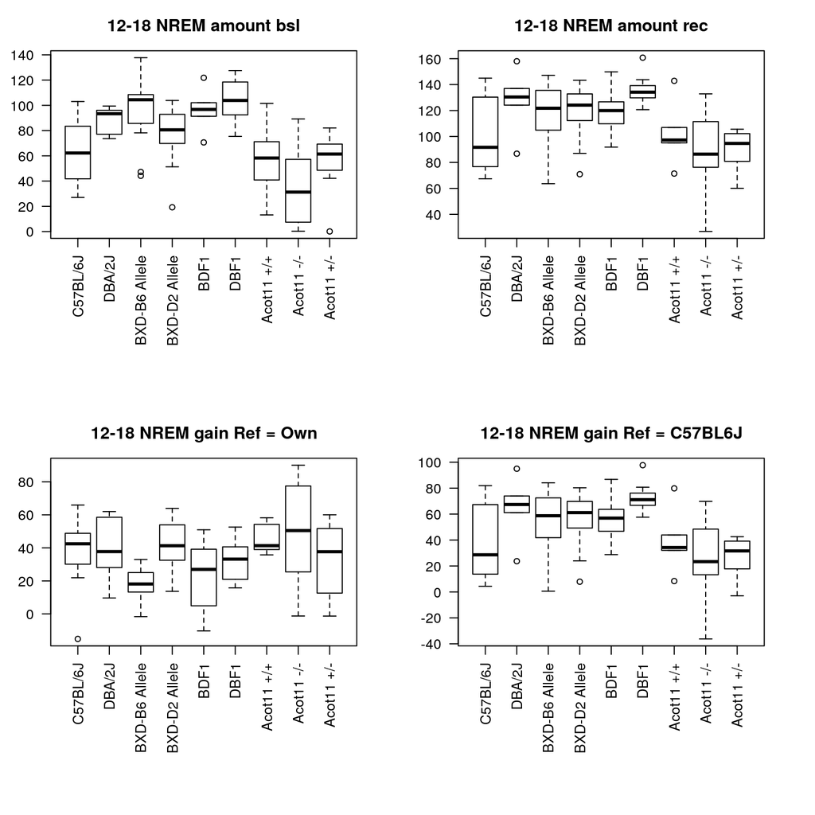

```r
par(mfrow=c(2,2))
interval<-"12-18"
ref<-"Own"
res<-GetGain(interval,ref)

boxplot(res$bsl,las=2,main=paste(interval,"NREM amount bsl"))
boxplot(res$rec,las=2,main=paste(interval,"NREM amount rec"))

boxplot(res$gain,las=2,main=paste(interval,"NREM gain","Ref = Own"))

ref<-"C57BL6J"
res<-GetGain(interval,ref)

boxplot(res$gain,las=2,main=paste(interval,"NREM gain","Ref = C57BL6J"))
```

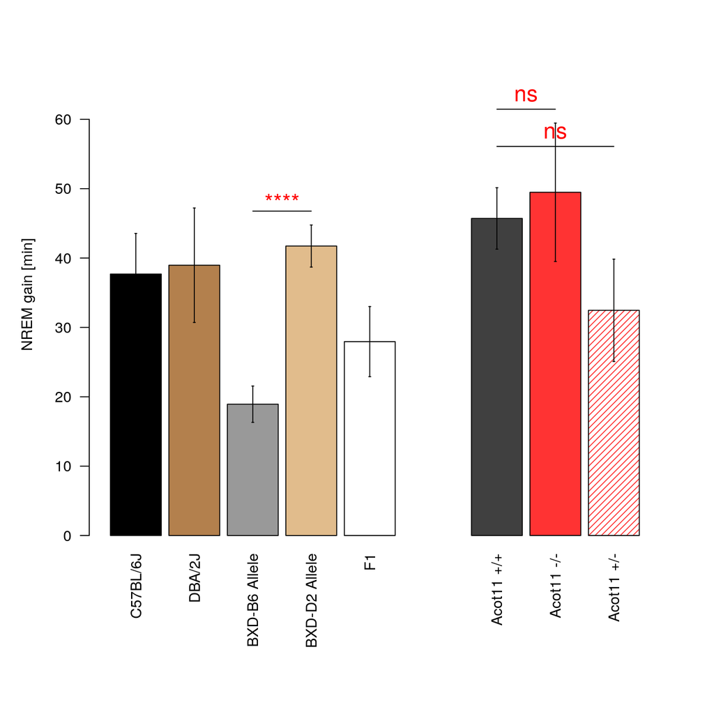

```r
ref<-"Own"
res<-GetGain(interval,ref)
par(mfrow=c(1,1))
plot_Barplot2(res$gain)
```

## ZT 18-24

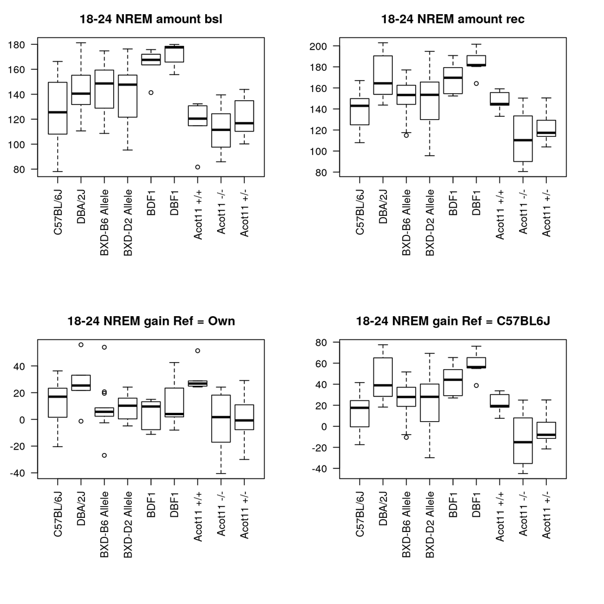

```r
par(mfrow=c(2,2))
interval<-"18-24"
ref<-"Own"
res<-GetGain(interval,ref)

boxplot(res$bsl,las=2,main=paste(interval,"NREM amount bsl"))
boxplot(res$rec,las=2,main=paste(interval,"NREM amount rec"))

boxplot(res$gain,las=2,main=paste(interval,"NREM gain","Ref = Own"))

ref<-"C57BL6J"
res<-GetGain(interval,ref)

boxplot(res$gain,las=2,main=paste(interval,"NREM gain","Ref = C57BL6J"))
```

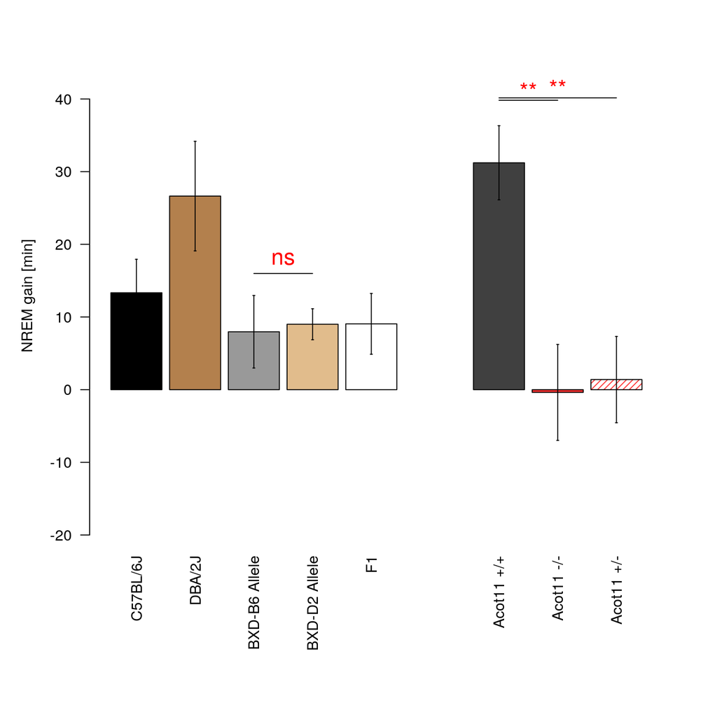

```r
ref<-"Own"
res<-GetGain(interval,ref)
par(mfrow=c(1,1))
plot_Barplot2(res$gain)
```

## ZT 12-24

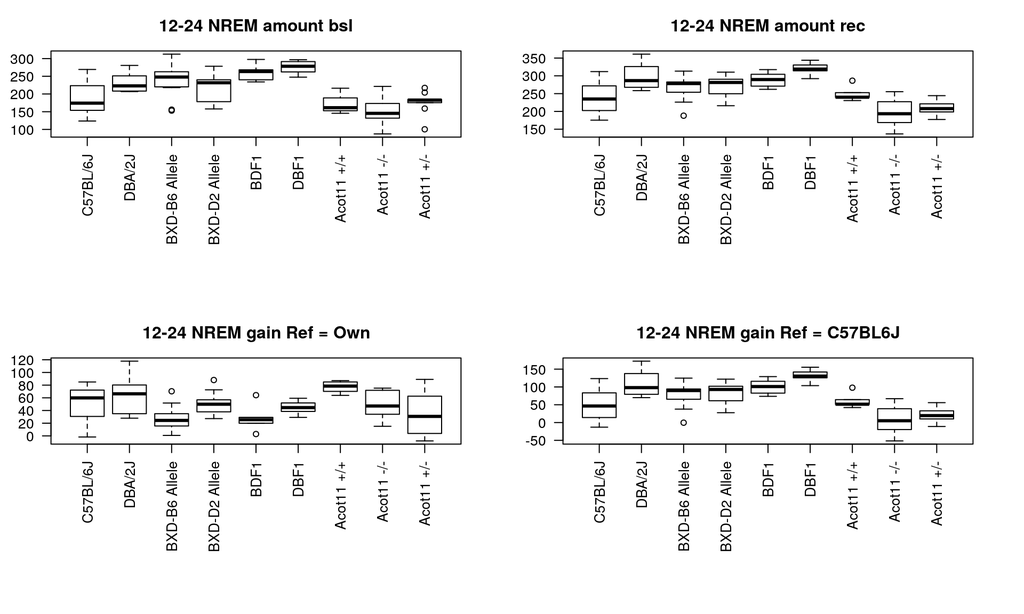

```r
par(mfrow=c(2,2))
interval<-"12-24"
ref<-"Own"
res<-GetGain(interval,ref)

boxplot(res$bsl,las=2,main=paste(interval,"NREM amount bsl"))
boxplot(res$rec,las=2,main=paste(interval,"NREM amount rec"))

boxplot(res$gain,las=2,main=paste(interval,"NREM gain","Ref = Own"))

ref<-"C57BL6J"
res<-GetGain(interval,ref)

boxplot(res$gain,las=2,main=paste(interval,"NREM gain","Ref = C57BL6J"))
```

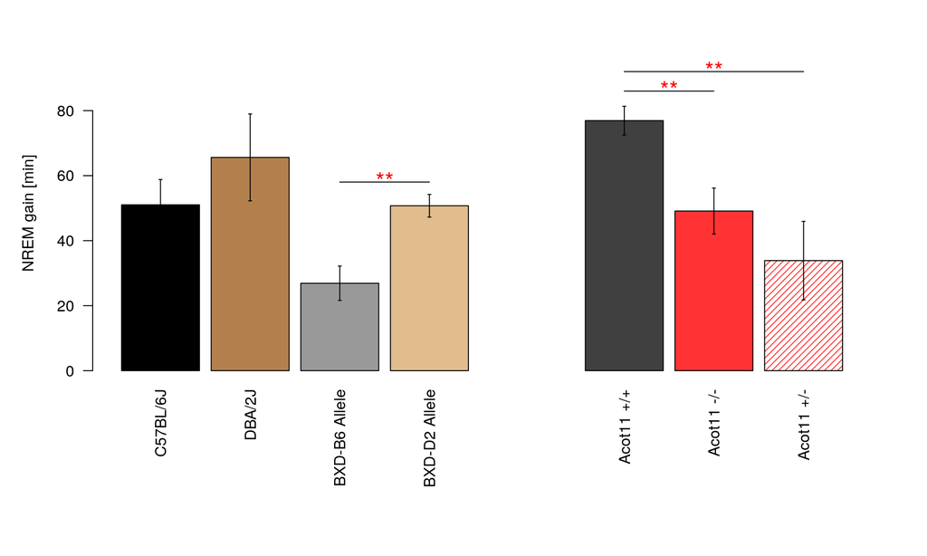

```r
ref<-"Own"
res<-GetGain(interval,ref)
par(mfrow=c(1,1))


plot_Barplot2(res$gain,NOF1=TRUE)
```

```r
pdf(file="ZT12_24_KOValidation.pdf",height = 6,width = 10)
plot_Barplot2(res$gain,NOF1=TRUE)
dev.off()
```

## ZT 24h

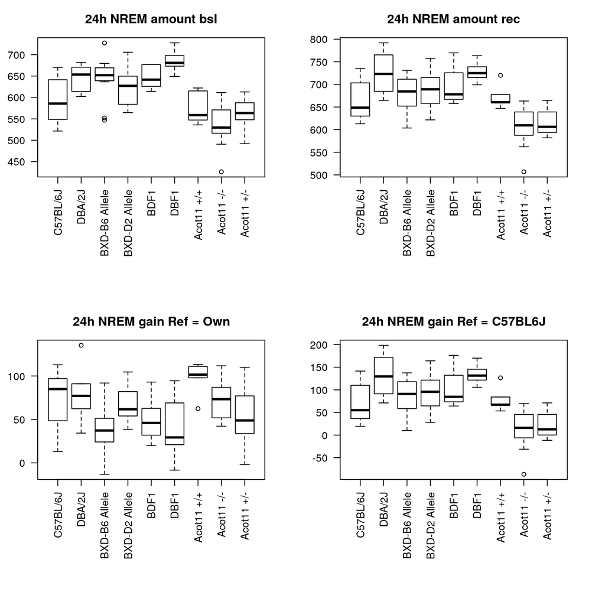

```r
par(mfrow=c(2,2))
interval<-"24h"
ref<-"Own"
res<-GetGain(interval,ref)

boxplot(res$bsl,las=2,main=paste(interval,"NREM amount bsl"))
boxplot(res$rec,las=2,main=paste(interval,"NREM amount rec"))

boxplot(res$gain,las=2,main=paste(interval,"NREM gain","Ref = Own"))

ref<-"C57BL6J"
res<-GetGain(interval,ref)

boxplot(res$gain,las=2,main=paste(interval,"NREM gain","Ref = C57BL6J"))
```

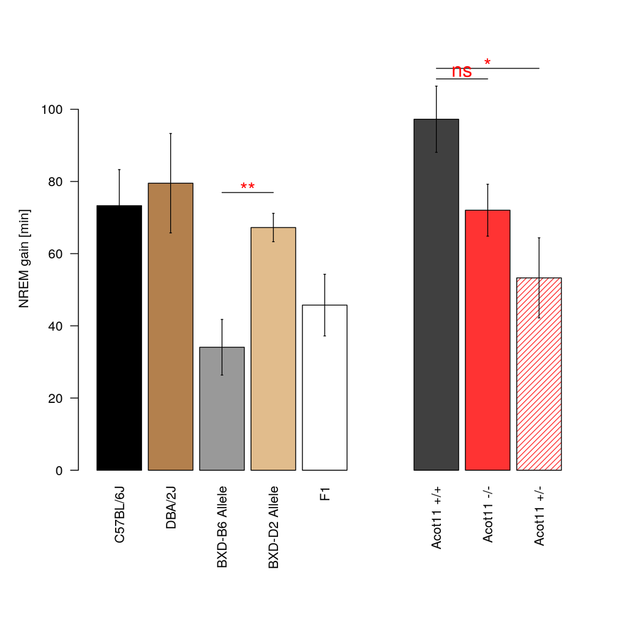

```r
ref<-"Own"
res<-GetGain(interval,ref)
par(mfrow=c(1,1))
plot_Barplot2(res$gain)
```

```r
interval<-"18-24"
ref<-"Own"
res1824<-GetGain(interval,ref)
```

# Text:

```r
# ZT12-18
res1218<-GetGain("12-18","Own")
ZT1218_WTGain<-round(mean(res1218$gain$`Acot11 +/+`),1)
ZT1218_KOGain<-round(mean(res1218$gain$`Acot11 -/-`),1)
ZT1218_PvalKOvsWT<-round(t.test(res1218$gain$`Acot11 +/+`,res1218$gain$`Acot11 -/-`)$p.value,4)
ZT1218_BL6JGain<-round(mean(res1218$gain$`C57BL/6J`),1)

# ZT12-24
res1224<-GetGain("12-24","Own")
ZT1224_WTGain<-round(mean(res1224$gain$`Acot11 +/+`),1)
ZT1224_KOGain<-round(mean(res1224$gain$`Acot11 -/-`),1)
ZT1224_PvalKOvsWT<-round(t.test(res1224$gain$`Acot11 +/+`,res1224$gain$`Acot11 -/-`)$p.value,4)
ZT1224_BL6JGain<-round(mean(res1224$gain$`C57BL/6J`),1)

# ZT18-24
res1824<-GetGain("18-24","Own")
ZT1824_WTGain<-round(mean(res1824$gain$`Acot11 +/+`),1)
ZT1824_KOGain<-round(mean(res1824$gain$`Acot11 -/-`),1)
ZT1824_PvalKOvsWT<-round(t.test(res1824$gain$`Acot11 +/+`,res1824$gain$`Acot11 -/-`)$p.value,4)
ZT1824_BL6JGain<-round(mean(res1824$gain$`C57BL/6J`),1)
```

In order to control for Acot11 effect on NREM sleep gain, we contrasted global Acot11 KO and heterozygous mice (REF Zhang et al. 2012 ?) with their corresponding C57BL6(N?J?) wild-type background using same sleep deprivation design used for BXD lines. While for the BXD lines, the effect of Acot11 was detected with the strongest effect on the first 6h of the dark phase [ZT:12-18] where most sleep compensation occured, we did not detect a significant change of NREM gain for Acot11 KO in this specific interval. However, over the whole dark period and specifically during the second 6h interval of the dark phase [ZT:18-24], a lower gain of NREM sleep was observed for Acot11 KO and HT compared to WT. In this interval, WT mice gained 31.2 minutes of NREM sleep while Acot11 KO gained only -0.4 minutes of NREM sleep (P.value = 0.0023). It was intersting to notice that most NREM sleep gain for C57BL/6J substrain occured during the first hours of the dark (ZT:12-18: 37.7 min, ZT:18-24: 13.3 min), while C57BL6(N?) mice compensated also during the second interval (ZT:12-18: 45.7 min, ZT:18-24: 31.2 min), where we detected Acot11 effect. Over the whole dark period [ZT:12-24], Acot11 KO gained 49.1 minutes of NREM sleep while WT mice gained 76.9 minutes (P.value = 0.0054). This difference over the whole dark period could also be observed for the BXD. (Figure barplot). The difference of genetic background used between BXD and Acot11 KO, and the interaction with DBA/2J variation within BXD lines, can explain the different time phase effect of Acot11 that we observe on NREM sleep compensation in the dark.

Jax blog: https://www.jax.org/news-and-insights/jax-blog/2016/june/there-is-no-such-thing-as-a-b6-mouse